# Assignment #03: exceptions and testing

Since last week you have learned two important new concepts: unit testing and exceptions handling. In today's assignment we will revisit last week's code in order to properly test it and make it more robust.

In exercise #03-02 we will learn the basics of numpy and matplotlib in order to display live meteorological data.

**Note: for these exercises you are allowed to use the numpy and matplotlib libraries only! No external module is allowed (with the exception of the standard library of course).**

## Exercise #03-01: refactor and test last week's code

- **Write a test suite for both exercises from last week** (one `test_*.py` file per module). The test suite must contain unit tests for each function you programmed (I myself wrote 4 functions for exercise #02-01 and 3 for exercise #02-02).
- **Apply the exception handling methods learned in lesson 09 to the download function(s) of exercise #02-02**. Add a test to your test suite to verify that exceptions are raised when an invalid tile is requested for download.

## Tutorials: getting started with numpy and matplotlib

[numpy](http://www.numpy.org/) and [matplotlib](https://matplotlib.org/) are two fundamental pillars of the scientific python stack. You will find *numerous* tutorials for both libraries online. I am asking you to learn the basics of both tools by yourself, at the pace that suits you. Personally I recommend to follow these two tutorials from the Scipy Lecture Notes for a start:

- [numpy tutorial](https://www.scipy-lectures.org/intro/numpy/index.html)
- [matplotlib tutorial](https://www.scipy-lectures.org/intro/matplotlib/index.html)

## Exercise #03-02: ACINN meteorological data

The institute website provides live visualization of meteorological data: http://acinn.uibk.ac.at/current-weather/innsbruck-university . The raw data used for the plots are available in a live feed at the following addresses:

- http://acinn.uibk.ac.at/innsbruck/3 for the three days data
- http://acinn.uibk.ac.at/innsbruck/7 for the seven days data

The data for the other stations are available, per analogy:

- http://acinn.uibk.ac.at/ellboegen/3
- http://acinn.uibk.ac.at/obergurgl/3
- http://acinn.uibk.ac.at/sattelberg/3

The data is shared by ACINN under a [Creative Commons Attribution-ShareAlike 4.0 International License](https://creativecommons.org/licenses/by-sa/4.0/).

The data is provided in the [json](https://www.json.org/) format, often used for web applications. Fortunately, this is very easy to read in python:

```python
from urllib.request import Request, urlopen
import json

url = 'http://acinn.uibk.ac.at/innsbruck/3'
# Parse the given url
req = urlopen(Request(url)).read()
# Read the data
data = json.loads(req.decode('utf-8'))
```

Now I will help you to parse the timestamp of the data:

```python
from datetime import datetime, timedelta
data['time'] = [datetime(1970, 1, 1) + timedelta(milliseconds=ds) for ds in data['datumsec']]
```

And make a first plot to get you started:

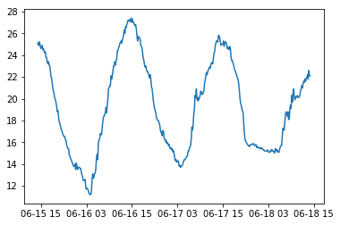

```python
%matplotlib inline
import matplotlib.pyplot as plt
plt.plot(data['time'], data['tl']);
```

**Your main task is to write a script that accepts three arguments: station name, variable name, and a number of days (3 or 7, defaults to 3). The variable name might be of: `['temperature', 'dewpoint_temperature', 'relative_humidity', 'windspeed', 'winddirection', 'pressure', 'precipitation', 'sunshine_duration']`. The script then displays a plot of the desired variable. The plot must contain the following information: variable name, variable description, unit. If the variable is not available, the script must print a warning and exit.**

Here are some hints to get you started:

- write several functions!
- preprocess the data: rename the variables using a conversion table between the original variable names and the more human readable name of above. Add the metadata to the data, with at least two attributes: `'description'` and `'units'`. A possible way to organize your data would be with the help of nested dictionaries.
- write a function to convert dewpoint and temperature to relative humidity. It must be called only if necessary.
- write a function to convert temperature and relative humidity to dewpoint temperature. It must be called only if necessary.
- write tests!

## Exercise #03-03: wind

**Based on the data from exercise #03-02, write a function that prints the following information in the terminal:**

```
At station XXX, over the last 3 days, the dominant wind direction was XX (xx% of the time). The second most dominant wind direction was XX (xx% of the time), the least dominant wind direction was XX (xx% of the time). The maximum wind speed was XX m/s, while the strongest wind speed averaged over an hour was XX m/s.
```

With the wind directions being of 8 classes: N, NW, W, SW, S, SE, E, NE.

*Back to the table of contents*